# MPDW Pertemuan1

Azizah

2023-09-04

Mengaktivasi packages yang akan digunakan

```r
library("forecast")
```

```r
library("graphics")
library("TTR")
library("TSA")
```

# Import data

```r
library(rio)
library(readxl)
```

memasukkan Data yang akan digunakan

```r
datam1<-import("https://raw.githubusercontent.com/azizahaa/MPDW-Prak/main/P1/Data%20Harga%20Daging%20Sapi.csv")
```

# Eksplorasi Data

Melihat data menggunakan fungsi `View()`, struktur data menggunakan fungsi `str()`, dan dimensi data menggunakan fungsi `dim()`.

```r
View(datam1)
str(datam1)
```

```
## 'data.frame':    140 obs. of  2 variables:
##  $ Bulan      : chr  "Dec  2020 (IV)" "Jan  2021 (I)" "Jan  2021 (II)" "Jan  2021 (III)" ...
##  $ Daging_Sapi: int  105600 105600 105600 105950 107300 107300 107300 107300 106800 107450 ...
```

```r
datam1[,1]<-matrix(c(1:140))
colnames(datam1)<-c("Minggu","Daging_Sapi")
dim(datam1)
```

```
## [1] 140   2
```

Mengubah data agar terbaca sebagai data deret waktu dengan fungsi `ts()` .

```r
datam1.ts <-ts(datam1$Daging_Sapi)
datam1.ts
```

```
## Time Series:
## Start = 1
## End = 140
## Frequency = 1
##   [1] 105600 105600 105600 105950 107300 107300 107300 107300 106800 107450
##  [11] 107450 107450 107450 107450 107450 107450 108750 110450 110450 110450
##  [21] 110450 115400 116650 116650 116650 115200 112650 112650 112650 113000
##  [31] 113750 113750 113750 113750 114750 113300 113300 113300 112200 110000
##  [41] 110000 110000 110000 110800 110800 110800 110800 110800 110800 110800
##  [51] 110800 110800 107450 107450 107450 107450 110750 111550 111550 111550
##  [61] 111550 109950 109950 109950 111300 114250 114250 114250 114550 121750
##  [71] 121750 121750 121750 122950 122600 122600 122600 122000 120850 120850
##  [81] 120850 121100 124850 124850 124850 124850 124000 122750 122750 122750
##  [91] 122500 121100 121100 121100 121100 121100 121100 121100 121100 121100
## [101] 121100 121100 121100 121100 121100 121100 121100 121100 121100 121100
## [111] 121100 121100 121100 121100 121100 121100 122000 123850 123850 123850
## [121] 124650 125900 126750 126750 126450 125950 125600 125600 125600 126150
## [131] 127300 127300 127300 127300 124200 123500 123500 123500 123750 124150
```

Menampilkan ringkasan data

```r
summary(datam1.ts)
```

```
##    Min. 1st Qu.  Median    Mean 3rd Qu.    Max.
##  105600  110800  120850  116907  122525  127300
```

Membuat plot deret waktu

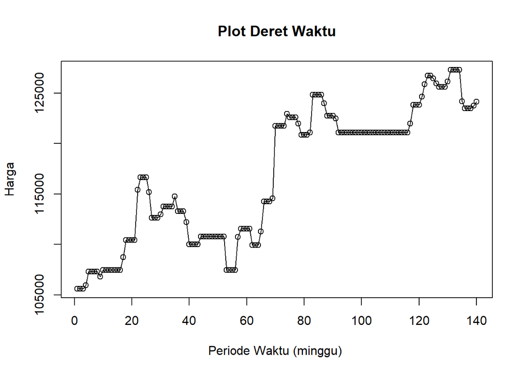

```r
ts.plot(datam1.ts, xlab="Periode Waktu (minggu) ", ylab="Harga",
        main = "Plot Deret Waktu")
points(datam1.ts)
```

Berdasarkan plot, data memiliki beberapa pola yaitu trend dan ada kemungkinan musiman ataupun siklik.

# Pemulusan

## Single Moving Average & Double Moving Average

Pembagian data latih dan data uji dilakukan dengan perbandingan 80% data latih dan 20% data uji.

```r
#membagi data latih dan data uji
b<-0.8*140
training_ma1 <- datam1[1:b,]
testing_ma1 <- datam1[(b+1):140,]
train_ma1.ts <- ts(training_ma1$Daging_Sapi)
test_ma1.ts <- ts(testing_ma1$Daging_Sapi)
```

### Eksplorasi Data

Eksplorasi data dilakukan pada keseluruhan data, data latih serta data uji menggunakan plot data deret waktu.

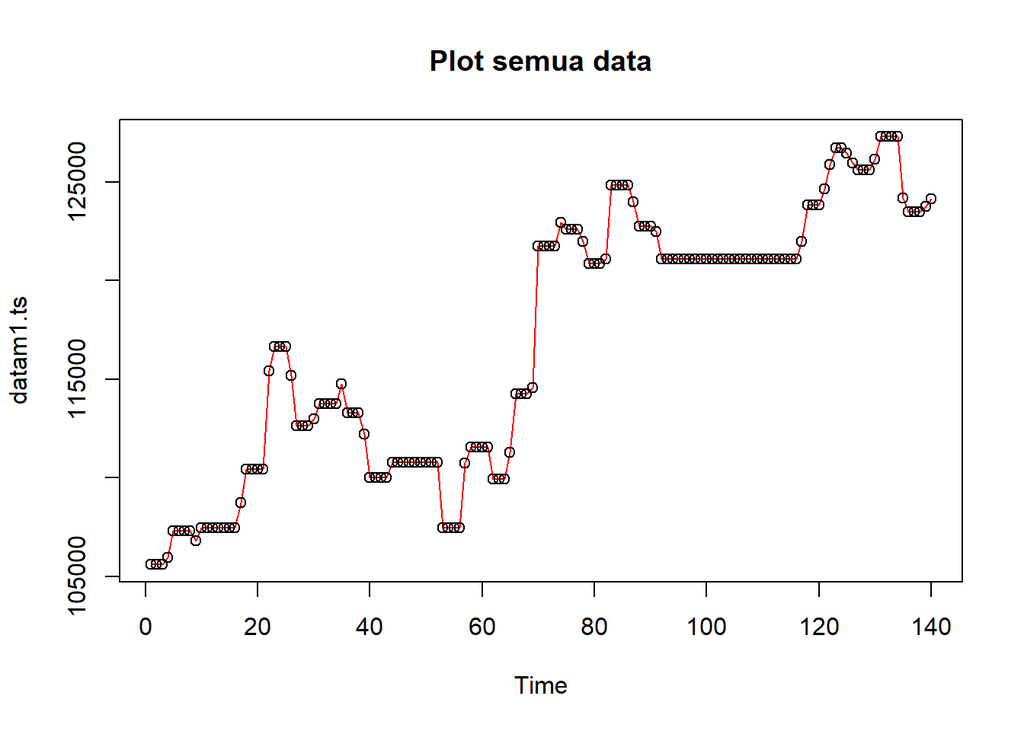

```r
#eksplorasi keseluruhan data
plot(datam1.ts, col="red",main="Plot semua data")
points(datam1.ts)
```

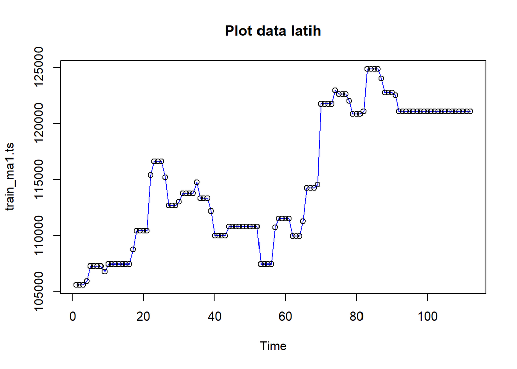

```r
#eksplorasi data latih
plot(train_ma1.ts, col="blue",main="Plot data latih")
points(train_ma1.ts)
```

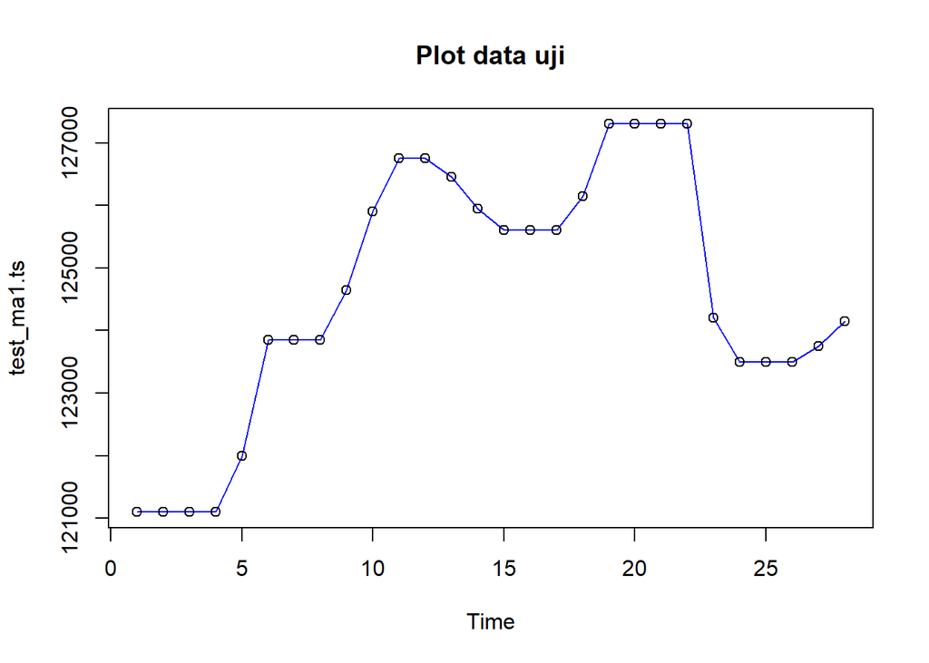

```r
#eksplorasi data uji
plot(test_ma1.ts, col="blue",main="Plot data uji")
points(test_ma1.ts)
```

Eksplorasi data juga dapat dilakukan menggunakan package `ggplot2` dengan terlebih dahulu memanggil library *package* `ggplot2`.

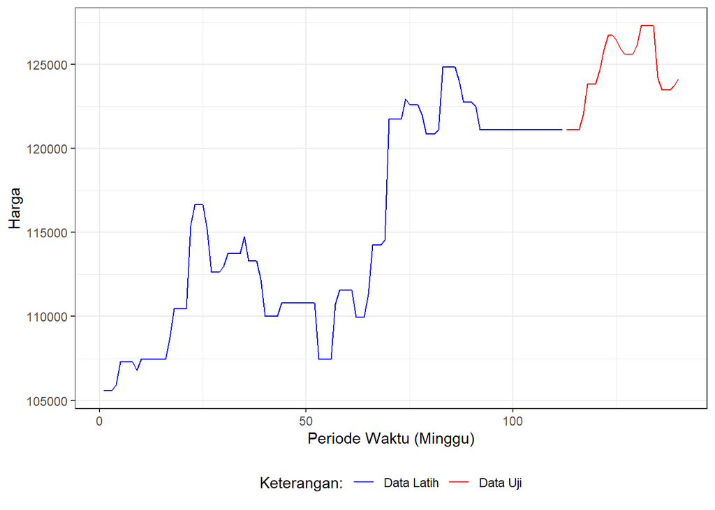

```r
#Eksplorasi dengan GGPLOT
library(ggplot2)
ggplot() +
  geom_line(data = training_ma1, aes(x = Minggu, y = Daging_Sapi, col = "Data Latih")) +
  geom_line(data = testing_ma1, aes(x = Minggu, y = Daging_Sapi, col = "Data Uji")) +
  labs(x = "Periode Waktu (Minggu)", y = "Harga", color = "Legend") +
  scale_colour_manual(name="Keterangan:", breaks = c("Data Latih", "Data Uji"),
                      values = c("blue", "red")) +
  theme_bw() + theme(legend.position = "bottom",
                     plot.caption = element_text(hjust=0.5, size=12))
```

### Double Moving Average (DMA)

Metode ini lebih cocok digunakan untuk pola data trend. Proses pemulusan dengan rata rata dalam metode ini dilakukan sebanyak 2 kali.

```r
data.sma1<-SMA(train_ma1.ts, n=2)
dma1 <- SMA(data.sma1, n = 2)
At1 <- 2*data.sma1 - dma1
Bt1 <- 2/(2-1)*(data.sma1 - dma1)
data.dma1<- At1+Bt1
data.ramal2<- c(NA, data.dma1)

t = 1:28
f = c()

for (i in t) {
  f[i] = At1[length(At1)] + Bt1[length(Bt1)]*(i)
}

data.gab2 <- cbind(aktual = c(train_ma1.ts,rep(NA,28)), pemulusan1 = c(data.sma1,rep(NA,28)),pemulusan2 = c(data.dma1, rep(NA,28)),At = c(At1, rep(NA,28)), Bt = c(Bt1,rep(NA,28)),ramalan = c(data.ramal2, f[-1]))
data.gab2
```

```
##        aktual pemulusan1 pemulusan2       At    Bt  ramalan
##   [1,] 105600         NA         NA       NA    NA       NA
##   [2,] 105600     105600         NA       NA    NA       NA
##   [3,] 105600     105600   105600.0 105600.0     0       NA
##   [4,] 105950     105775   106037.5 105862.5   175 105600.0
##   [5,] 107300     106625   107900.0 107050.0   850 106037.5
##   [6,] 107300     107300   108312.5 107637.5   675 107900.0
##   [7,] 107300     107300   107300.0 107300.0     0 108312.5
##   [8,] 107300     107300   107300.0 107300.0     0 107300.0
##   [9,] 106800     107050   106675.0 106925.0  -250 107300.0
##  [10,] 107450     107125   107237.5 107162.5    75 106675.0
##  [11,] 107450     107450   107937.5 107612.5   325 107237.5
##  [12,] 107450     107450   107450.0 107450.0     0 107937.5
##  [13,] 107450     107450   107450.0 107450.0     0 107450.0
##  [14,] 107450     107450   107450.0 107450.0     0 107450.0
```

[output cut: 126 more lines]

Hasil pemulusan menggunakan metode DMA divisualisasikan sebagai berikut

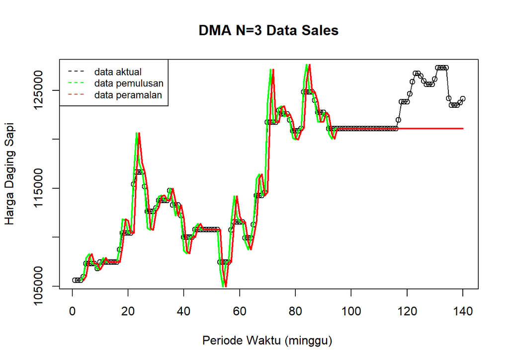

```r
ts.plot(datam1.ts, xlab="Periode Waktu (minggu) ", ylab="Harga Daging Sapi", main= "DMA N=3 Data Sales")
points(datam1.ts)
lines(data.gab2[,3],col="green",lwd=2)
lines(data.gab2[,6],col="red",lwd=2)
legend("topleft",c("data aktual","data pemulusan","data peramalan"), lty=8, col=c("black","green","red"), cex=0.8)
```

Selanjutnya perhitungan akurasi dilakukan baik pada data latih maupun data uji. Perhitungan akurasi dilakukan dengan ukuran akurasi SSE, MSE dan MAPE.

#### Akurasi Data Latih

```r
#Menghitung nilai keakuratan data latih
error_train.dma1 = train_ma1.ts-data.ramal2[1:length(train_ma1.ts)]
SSE_train.dma1 = sum(error_train.dma1[4:length(train_ma1.ts)]^2)
MSE_train.dma1 = mean(error_train.dma1[4:length(train_ma1.ts)]^2)
MAPE_train.dma1 = mean(abs((error_train.dma1[4:length(train_ma1.ts)]/train_ma1.ts[4:length(train_ma1.ts)])*100))

akurasi_train.dma1 <- matrix(c(SSE_train.dma1, MSE_train.dma1, MAPE_train.dma1))
row.names(akurasi_train.dma1)<- c("SSE", "MSE", "MAPE")
colnames(akurasi_train.dma1) <- c("Akurasi m = 2")
akurasi_train.dma1
```

```
##      Akurasi m = 2
## SSE   2.597991e+08
## MSE   2.383478e+06
## MAPE  8.107283e-01
```

#### Akurasi Data Uji

```r
#Menghitung nilai keakuratan data uji
error_test.dma1 = test_ma1.ts-data.gab2[113:140,6]
SSE_test.dma1 = sum(error_test.dma1^2)
MSE_test.dma1 = mean(error_test.dma1^2)
MAPE_test.dma1 = mean(abs((error_test.dma1/test_ma1.ts*100)))

akurasi_test.dma1 <- matrix(c(SSE_test.dma1, MSE_test.dma1, MAPE_test.dma1))
row.names(akurasi_test.dma1)<- c("SSE", "MSE", "MAPE")
colnames(akurasi_test.dma1) <- c("Akurasi m = 2")
akurasi_test.dma1
```

```
##      Akurasi m = 2
## SSE   4.583575e+08
## MSE   1.636991e+07
## MAPE  2.793340e+00
```

## Single Exponential Smoothing & Double Exponential Smoothing

Metode *Exponential Smoothing* adalah metode pemulusan dengan melakukan pembobotan menurun secara eksponensial. Nilai yang lebih baru diberi bobot yang lebih besar dari nilai terdahulu. Terdapat satu atau lebih parameter pemulusan yang ditentukan secara eksplisit, dan hasil pemilihan parameter tersebut akan menentukan bobot yang akan diberikan pada nilai pengamatan. Ada dua macam model, yaitu model tunggal dan ganda.

### Pembagian Data

Pembagian data latih dan data uji dilakukan dengan perbandingan 80% data latih dan 20% data uji.

```r
#membagi training dan testing
training2<-datam1[1:112,]
testing2<-datam1[113:140,]
train2.ts <- ts(training2$Daging_Sapi)
test2.ts <- ts(testing2$Daging_Sapi)
```

### Eksplorasi

Eksplorasi dilakukan dengan membuat plot data deret waktu untuk keseluruhan data, data latih, dan data uji.

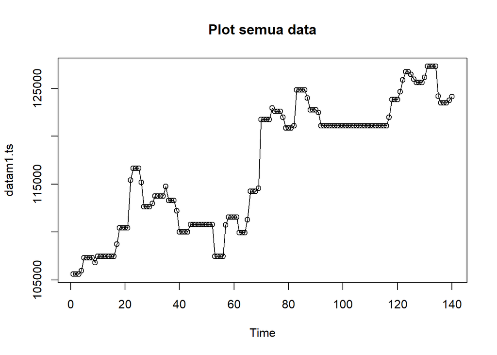

```r
#eksplorasi data
plot(datam1.ts, col="black",main="Plot semua data")
points(datam1.ts)
```

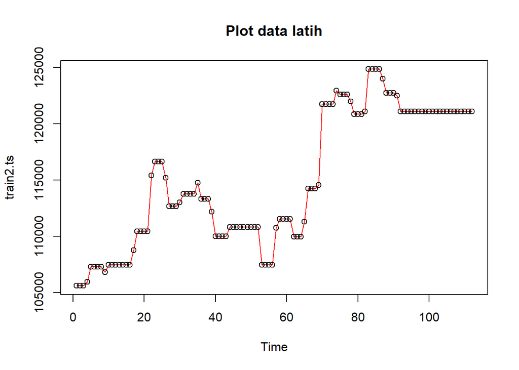

```r
plot(train2.ts, col="red",main="Plot data latih")
points(train2.ts)
```

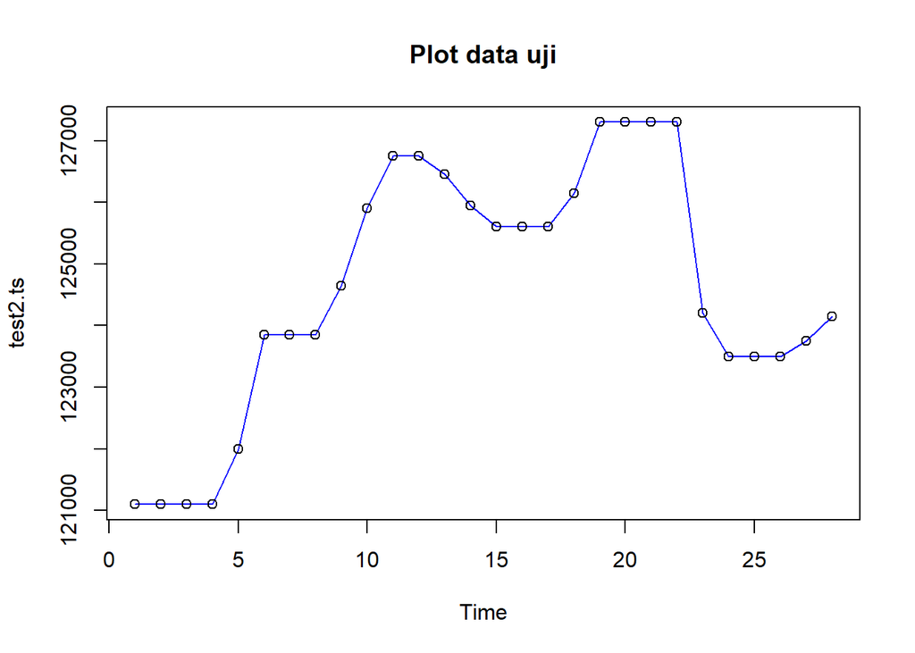

```r
plot(test2.ts, col="blue",main="Plot data uji")
points(test2.ts)
```

Eksplorasi data juga dapat dilakukan menggunakan package `ggplot2` .

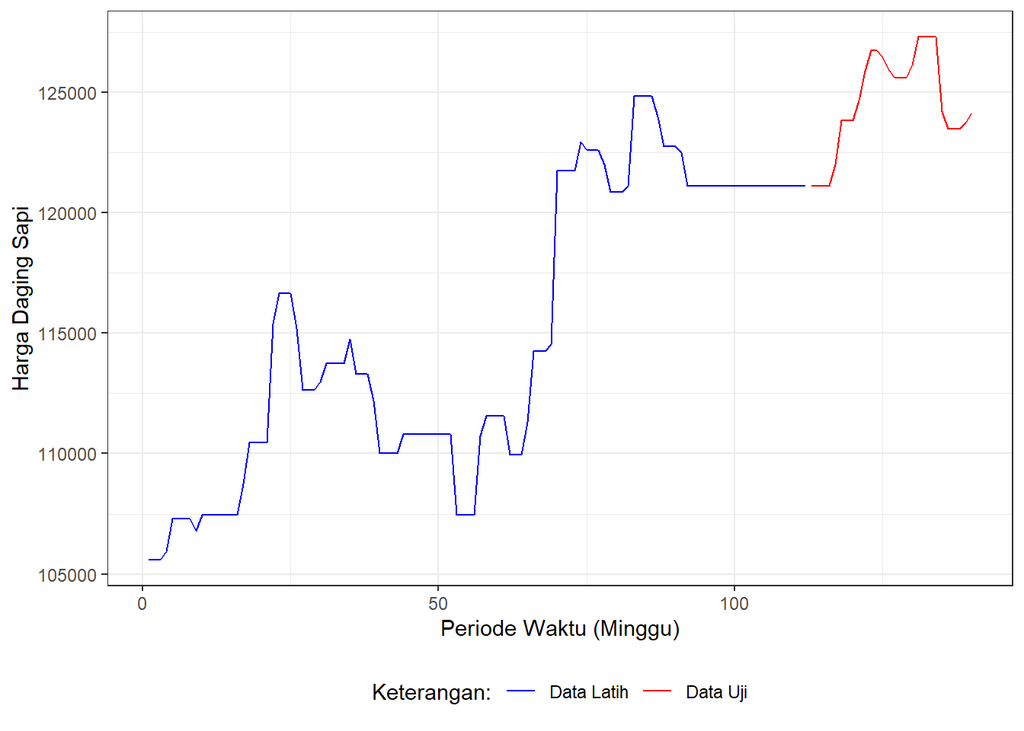

```r
#Eksplorasi dengan GGPLOT
library(ggplot2)
ggplot() +
  geom_line(data = training2, aes(x = Minggu, y = Daging_Sapi, col = "Data Latih")) +
  geom_line(data = testing2, aes(x = Minggu, y = Daging_Sapi, col = "Data Uji")) +
  labs(x = "Periode Waktu (Minggu)", y = "Harga Daging Sapi", color = "Legend") +
  scale_colour_manual(name="Keterangan:", breaks = c("Data Latih", "Data Uji"),
                      values = c("blue", "red")) +
  theme_bw() + theme(legend.position = "bottom",
                     plot.caption = element_text(hjust=0.5, size=12))
```

### DES

Metode pemulusan *Double Exponential Smoothing* (DES) digunakan untuk data yang memiliki pola tren. Metode DES adalah metode semacam SES, hanya saja dilakukan dua kali, yaitu pertama untuk tahapan ‘level’ dan kedua untuk tahapan ‘tren’. Pemulusan menggunakan metode ini akan menghasilkan peramalan tidak konstan untuk periode berikutnya.

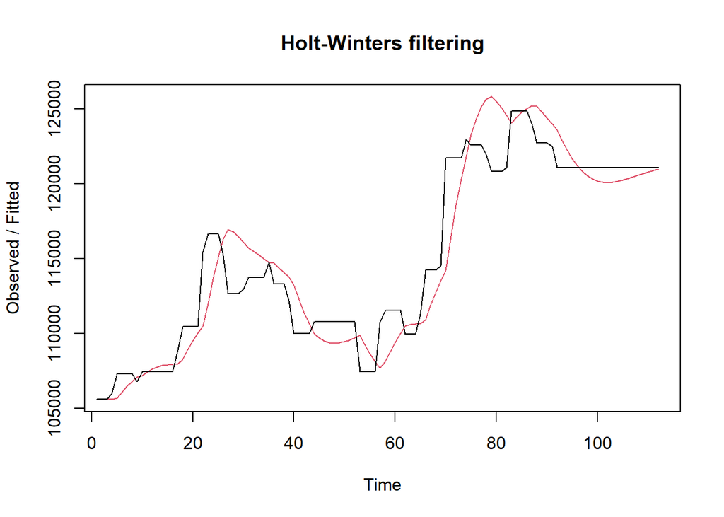

```r
#Lamda=0.2 dan gamma=0.2
des.1<- HoltWinters(train2.ts, gamma = FALSE, beta = 0.2, alpha = 0.2)
plot(des.1)
```

```r
#ramalan
ramalandes1<- forecast(des.1, h=28)
ramalandes1
```

```
##     Point Forecast    Lo 80    Hi 80    Lo 95    Hi 95
## 113       121055.4 118353.0 123757.7 116922.5 125188.2
## 114       121104.7 118325.7 123883.8 116854.5 125354.9
## 115       121154.1 118273.9 124034.3 116749.2 125559.0
## 116       121203.4 118196.2 124210.7 116604.3 125802.6
## 117       121252.8 118092.1 124413.5 116418.9 126086.6
## 118       121302.1 117961.7 124642.5 116193.4 126410.8
## 119       121351.5 117805.8 124897.2 115928.8 126774.2
## 120       121400.8 117625.3 125176.4 115626.7 127175.0
## 121       121450.2 117421.6 125478.7 115289.1 127611.3
## 122       121499.5 117196.1 125802.9 114918.1 128081.0
## 123       121548.9 116950.2 126147.6 114515.8 128582.0
## 124       121598.3 116685.1 126511.4 114084.2 129112.3
## 125       121647.6 116402.0 126893.2 113625.2 129670.0
## 126       121697.0 116102.2 127291.7 113140.5 130253.4
## 127       121746.3 115786.5 127706.1 112631.5 130861.1
## 128       121795.7 115455.9 128135.5 112099.8 131491.6
## 129       121845.0 115111.1 128579.0 111546.4 132143.7
## 130       121894.4 114752.9 129035.9 110972.4 132816.3
## 131       121943.7 114381.9 129505.6 110378.8 133508.6
## 132       121993.1 113998.6 129987.6 109766.6 134219.6
## 133       122042.4 113603.6 130481.3 109136.3 134948.6
## 134       122091.8 113197.2 130986.3 108488.8 135694.8
## 135       122141.1 112780.0 131502.3 107824.5 136457.7
## 136       122190.5 112352.3 132028.7 107144.2 137236.8
## 137       122239.8 111914.3 132565.4 106448.3 138031.4
## 138       122289.2 111466.4 133112.0 105737.2 138841.2
## 139       122338.6 111008.9 133668.2 105011.3 139665.8
## 140       122387.9 110542.0 134233.8 104271.1 140504.7
```

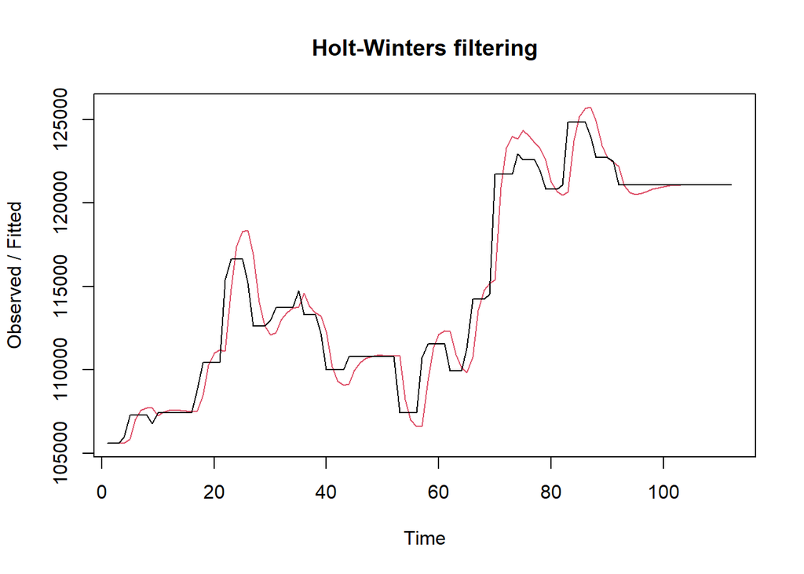

```r
#Lamda=0.6 dan gamma=0.3
des.2<- HoltWinters(train2.ts, gamma = FALSE, beta = 0.3, alpha = 0.6)
plot(des.2)
```

```r
#ramalan
ramalandes2<- forecast(des.2, h=28)
ramalandes2
```

```
##     Point Forecast     Lo 80    Hi 80     Lo 95    Hi 95
## 113       121100.2 119233.28 122967.2 118244.98 123955.5
## 114       121100.3 118732.58 123468.0 117479.18 124721.4
## 115       121100.4 118130.79 124069.9 116558.80 125641.9
## 116       121100.4 117446.92 124753.9 115512.87 126688.0
## 117       121100.5 116693.53 125507.4 114360.63 127840.3
## 118       121100.5 115879.08 126322.0 113115.01 129086.1
## 119       121100.6 115009.54 127191.7 111785.12 130416.1
## 120       121100.7 114089.28 128112.1 110377.67 131823.7
## 121       121100.7 113121.70 129079.7 108897.86 133303.6
## 122       121100.8 112109.53 130092.0 107349.84 134851.7
## 123       121100.8 111054.99 131146.7 105737.04 136464.7
## 124       121100.9 109959.99 132241.8 104062.34 138139.5
## 125       121101.0 108826.15 133375.8 102328.25 139873.7
## 126       121101.0 107654.90 134547.2 100536.94 141665.1
## 127       121101.1 106447.50 135754.7  98690.35 143511.8
## 128       121101.2 105205.09 136997.2  96790.22 145412.1
## 129       121101.2 103928.69 138273.8  94838.10 147364.3
## 130       121101.3 102619.23 139583.3  92835.42 149367.1
## 131       121101.3 101277.57 140925.1  90783.49 151419.2
## 132       121101.4  99904.49 142298.3  88683.52 153519.3
## 133       121101.5  98500.72 143702.2  86536.62 155666.3
## 134       121101.5  97066.95 145136.1  84343.82 157859.2
## 135       121101.6  95603.81 146599.4  82106.10 160097.1
## 136       121101.6  94111.88 148091.4  79824.36 162378.9
## 137       121101.7  92591.73 149611.7  77499.45 164704.0
## 138       121101.8  91043.88 151159.7  75132.19 167071.4
## 139       121101.8  89468.82 152734.8  72723.32 169480.4
## 140       121101.9  87867.04 154336.8  70273.57 171930.2
```

Selanjutnya jika ingin membandingkan plot data latih dan data uji adalah sebagai berikut.

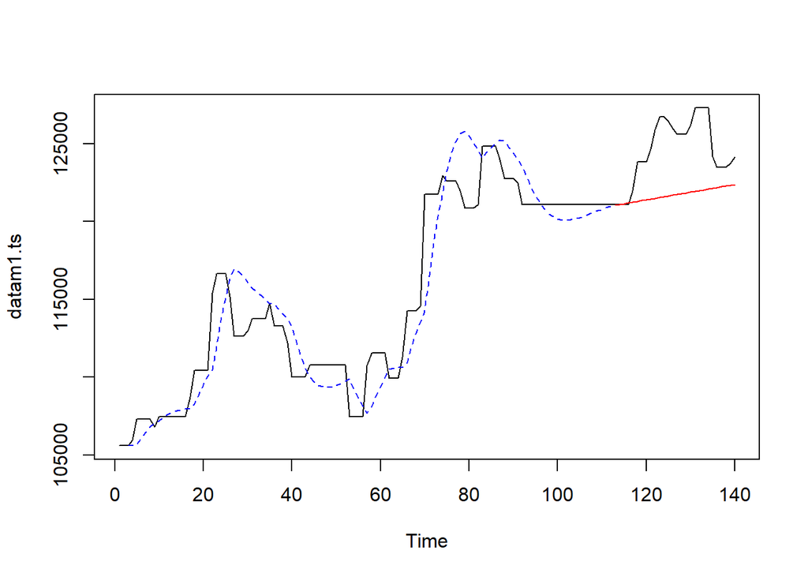

```r
#Visually evaluate the prediction
plot(datam1.ts)
lines(des.1$fitted[,1], lty=2, col="blue")
lines(ramalandes1$mean, col="red")
```

Untuk mendapatkan nilai parameter optimum dari DES, argumen `alpha` dan `beta` dapat dibuat `NULL` seperti berikut.

```r
#Lamda dan gamma optimum
des.opt<- HoltWinters(train2.ts, gamma = FALSE)
des.opt
```

```
## Holt-Winters exponential smoothing with trend and without seasonal component.
##
## Call:
## HoltWinters(x = train2.ts, gamma = FALSE)
##
## Smoothing parameters:
##  alpha: 1
##  beta : 0.002767936
##  gamma: FALSE
##
## Coefficients:
##           [,1]
## a 121100.00000
## b     35.74488
```

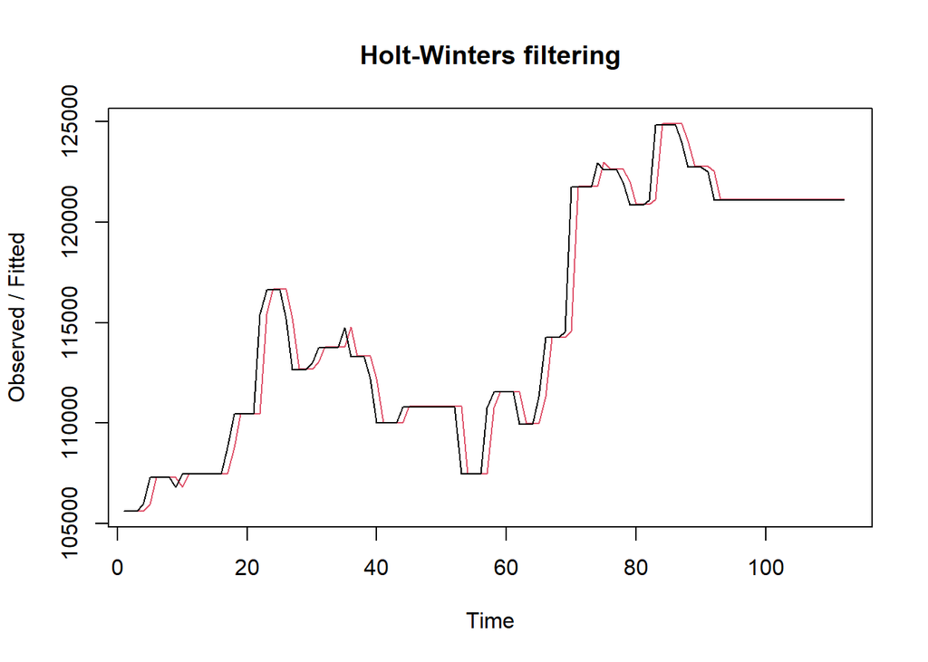

```r
plot(des.opt)
```

```r
#ramalan
ramalandesopt<- forecast(des.opt, h=28)
ramalandesopt
```

```
##     Point Forecast    Lo 80    Hi 80    Lo 95    Hi 95
## 113       121135.7 119582.2 122689.3 118759.8 123511.7
## 114       121171.5 118971.4 123371.6 117806.8 124536.2
## 115       121207.2 118509.0 123905.5 117080.6 125333.9
## 116       121243.0 118123.0 124363.0 116471.4 126014.6
## 117       121278.7 117785.7 124771.8 115936.5 126620.9
## 118       121314.5 117482.7 125146.2 115454.3 127174.6
## 119       121350.2 117205.8 125494.7 115011.8 127688.6
## 120       121386.0 116949.2 125822.7 114600.6 128171.3
## 121       121421.7 116709.4 126134.0 114214.8 128628.6
## 122       121457.4 116483.4 126431.5 113850.3 129064.6
## 123       121493.2 116269.2 126717.2 113503.8 129482.6
## 124       121528.9 116065.2 126992.7 113172.8 129885.0
## 125       121564.7 115870.0 127259.3 112855.4 130273.9
## 126       121600.4 115682.7 127518.2 112550.0 130650.8
## 127       121636.2 115502.4 127770.0 112255.3 131017.0
## 128       121671.9 115328.3 128015.5 111970.2 131373.7
## 129       121707.7 115159.9 128255.5 111693.7 131721.7
## 130       121743.4 114996.6 128490.2 111425.0 132061.8
## 131       121779.2 114838.0 128720.3 111163.6 132394.7
## 132       121814.9 114683.7 128946.1 110908.7 132721.1
## 133       121850.6 114533.4 129167.9 110659.9 133041.4
## 134       121886.4 114386.8 129386.0 110416.8 133356.0
## 135       121922.1 114243.6 129600.7 110178.8 133665.5
## 136       121957.9 114103.5 129812.2 109945.7 133970.1
## 137       121993.6 113966.5 130020.8 109717.1 134270.1
## 138       122029.4 113832.1 130226.6 109492.8 134565.9
## 139       122065.1 113700.4 130429.8 109272.4 134857.8
## 140       122100.9 113571.2 130630.5 109055.8 135145.9
```

Selanjutnya akan dilakukan perhitungan akurasi pada data latih maupun data uji dengan ukuran akurasi SSE, MSE dan MAPE.

#### Akurasi Data Latih

```r
#Akurasi Data Training
ssedes.train1<-des.1$SSE
msedes.train1<-ssedes.train1/length(train2.ts)
sisaandes1<-ramalandes1$residuals
head(sisaandes1)
```

```
## Time Series:
## Start = 1
## End = 6
## Frequency = 1
## [1]      NA      NA    0.00  350.00 1616.00 1214.16
```

```r
mapedes.train1 <- sum(abs(sisaandes1[3:length(train2.ts)]/train2.ts[3:length(train2.ts)])
                      *100)/length(train2.ts)

akurasides.1 <- matrix(c(ssedes.train1,msedes.train1,mapedes.train1))
row.names(akurasides.1)<- c("SSE", "MSE", "MAPE")
colnames(akurasides.1) <- c("Akurasi lamda=0.2 dan gamma=0.2")
akurasides.1
```

```
##      Akurasi lamda=0.2 dan gamma=0.2
## SSE                     4.846643e+08
## MSE                     4.327360e+06
## MAPE                    1.345080e+00
```

```r
ssedes.train2<-des.2$SSE
msedes.train2<-ssedes.train2/length(train2.ts)
sisaandes2<-ramalandes2$residuals
head(sisaandes2)
```

```
## Time Series:
## Start = 1
## End = 6
## Frequency = 1
## [1]      NA      NA    0.00  350.00 1427.00  250.94
```

```r
mapedes.train2 <- sum(abs(sisaandes2[3:length(train2.ts)]/train2.ts[3:length(train2.ts)])
                      *100)/length(train2.ts)

akurasides.2 <- matrix(c(ssedes.train2,msedes.train2,mapedes.train2))
row.names(akurasides.2)<- c("SSE", "MSE", "MAPE")
colnames(akurasides.2) <- c("Akurasi lamda=0.6 dan gamma=0.3")
akurasides.2
```

```
##      Akurasi lamda=0.6 dan gamma=0.3
## SSE                     2.313235e+08
## MSE                     2.065388e+06
## MAPE                    7.748239e-01
```

Hasil akurasi dari data latih didapatkan skenario 2 dengan lamda=0.6 dan gamma=0.3 memiliki hasil yang lebih baik yaitu dengan 0.77 %. Namun untuk kedua skenario dapat dikategorikan peramalan sangat baik berdasarkan nilai MAPE-nya.

#### Akurasi Data Uji

```r
#Akurasi Data Testing
selisihdes1<-ramalandes1$mean-testing2$Daging_Sapi
selisihdes1
```

```
## Time Series:
## Start = 113
## End = 140
## Frequency = 1
##  [1]   -44.631794     4.721359    54.074511   103.427664  -747.219183
##  [6] -2547.866030 -2498.512878 -2449.159725 -3199.806572 -4400.453419
## [11] -5201.100266 -5151.747114 -4802.393961 -4253.040808 -3853.687655
## [16] -3804.334503 -3754.981350 -4255.628197 -5356.275044 -5306.921891
## [21] -5257.568739 -5208.215586 -2058.862433 -1309.509280 -1260.156128
## [26] -1210.802975 -1411.449822 -1762.096669
```

```r
SSEtestingdes1<-sum(selisihdes1^2)
MSEtestingdes1<-SSEtestingdes1/length(testing2$Daging_Sapi)
MAPEtestingdes1<-sum(abs(selisihdes1/testing2$Daging_Sapi)*100)/length(testing2$Daging_Sapi)

selisihdes2<-ramalandes2$mean-testing2$Daging_Sapi
selisihdes2
```

```
## Time Series:
## Start = 113
## End = 140
## Frequency = 1
##  [1]     0.2330273     0.2946219     0.3562165     0.4178111  -899.5205942
##  [6] -2749.4589996 -2749.3974050 -2749.3358104 -3549.2742157 -4799.2126211
## [11] -5649.1510265 -5649.0894319 -5349.0278372 -4848.9662426 -4498.9046480
## [16] -4498.8430534 -4498.7814587 -5048.7198641 -6198.6582695 -6198.5966749
## [21] -6198.5350802 -6198.4734856 -3098.4118910 -2398.3502964 -2398.2887017
## [26] -2398.2271071 -2648.1655125 -3048.1039179
```

```r
SSEtestingdes2<-sum(selisihdes2^2)
MSEtestingdes2<-SSEtestingdes2/length(testing2$Daging_Sapi)
MAPEtestingdes2<-sum(abs(selisihdes2/testing2$Daging_Sapi)*100)/length(testing2$Daging_Sapi)

selisihdesopt<-ramalandesopt$mean-testing2$Daging_Sapi
selisihdesopt
```

```
## Time Series:
## Start = 113
## End = 140
## Frequency = 1
##  [1]    35.74488    71.48976   107.23464   142.97952  -721.27560 -2535.53072
##  [7] -2499.78584 -2464.04096 -3228.29608 -4442.55120 -5256.80632 -5221.06143
## [13] -4885.31655 -4349.57167 -3963.82679 -3928.08191 -3892.33703 -4406.59215
## [19] -5520.84727 -5485.10239 -5449.35751 -5413.61263 -2277.86775 -1542.12287
## [25] -1506.37799 -1470.63311 -1684.88823 -2049.14335
```

```r
SSEtestingdesopt<-sum(selisihdesopt^2)
MSEtestingdesopt<-SSEtestingdesopt/length(testing2$Daging_Sapi)
MAPEtestingdesopt<-sum(abs(selisihdesopt/testing2$Daging_Sapi)*100)/length(testing2$Daging_Sapi)

akurasitestingdes <-
  matrix(c(SSEtestingdes1,MSEtestingdes1,MAPEtestingdes1,SSEtestingdes2,MSEtestingdes2,
           MAPEtestingdes2,SSEtestingdesopt,MSEtestingdesopt,MAPEtestingdesopt),
         nrow=3,ncol=3)
row.names(akurasitestingdes)<- c("SSE", "MSE", "MAPE")
colnames(akurasitestingdes) <- c("des ske1","des ske2","des opt")
akurasitestingdes
```

```
##          des ske1     des ske2      des opt
## SSE  3.309123e+08 4.581226e+08 3.514601e+08
## MSE  1.181830e+07 1.636152e+07 1.255215e+07
## MAPE 2.306319e+00 2.792566e+00 2.400120e+00
```

Hasil akurasi dari data uji didapatkan skenario 1 dengan lamda=0.2 dan gamma=0.2 memiliki hasil yang lebih baik yaitu dengan 2.3 %. Namun untuk kedua skenario dapat dikategorikan peramalan sangat baik berdasarkan nilai MAPE-nya.

## Pemulusan Data Musiman

Pertama impor kembali data baru untuk latihan data musiman. Selanjutnya melakukan pembagian data dan mengubahnya menjadi data deret waktu.

```r
#membagi data menjadi training dan testing
training3<-datam1[1:112,2]
testing3<-datam1[113:140,2]
training.ts<-ts(training3, frequency =7)
testing.ts<-ts(testing3, frequency = 7)
```

Kemudian akan dilakukan eskplorasi dengan plot data deret waktu sebagai berikut.

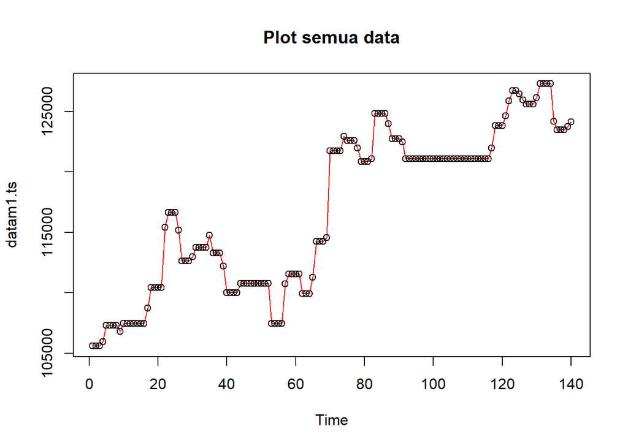

```r
#Membuat plot time series
plot(datam1.ts, col="red",main="Plot semua data")
points(datam1.ts)
```

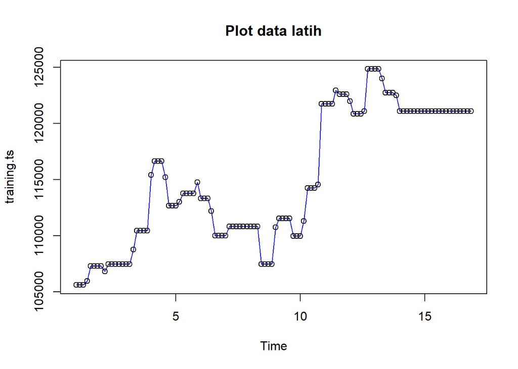

```r
plot(training.ts, col="blue",main="Plot data latih")
points(training.ts)
```

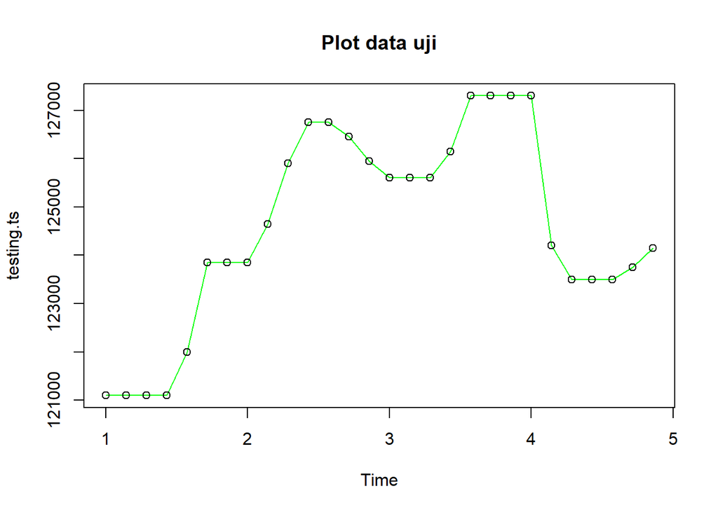

```r
plot(testing.ts, col="green",main="Plot data uji")
points(testing.ts)
```

Pemulusan data musiman dengan metode Winter dilakukan menggunakan fungsi `HoltWinters()` dengan memasukkan argumen tambahan, yaitu `gamma()` dan `seasonal()` . Arguman `seasonal()` diinisialisasi menyesuaikan jenis musiman, aditif atau multiplikatif.

### Winter Aditif

Perhitungan dengan model aditif dilakukan jika plot data asli menunjukkan fluktuasi musiman yang relatif stabil (konstan).

#### Pemulusan

```r
#Pemulusan dengan winter aditif
winter1 <- HoltWinters(training.ts,alpha=0.2,beta=0.1,gamma=0.1,seasonal = "additive")
winter1$fitted
```

```
## Time Series:
## Start = c(2, 1)
## End = c(16, 7)
## Frequency = 7
##               xhat    level        trend      season
##  2.000000 106407.0 106371.7  141.4115646 -106.122449
##  2.142857 106223.4 106691.7  159.2721088 -627.551020
##  2.285714 107138.1 106966.3  170.8036735    1.020408
##  2.428571 107084.7 107199.5  177.0414231 -291.836735
##  2.571429 108177.8 107449.6  184.3479373  543.877551
##  2.714286 108030.6 107488.4  169.7919041  372.448980
##  2.857143 107808.4 107542.0  158.1798109  108.163265
##  3.000000 107744.9 107628.5  151.0122544  -34.680272
##  3.142857 107284.3 107720.6  145.1148349 -581.424762
##  3.285714 108073.2 107898.8  148.4294924   25.971407
##  3.428571 108082.0 108182.6  161.9647051 -262.610678
##  3.571429 109513.2 108818.2  209.3252230  485.653418
##  3.714286 109768.9 109214.9  228.0618508  326.000607
##  3.857143 109900.3 109579.2  241.6829723   79.493039
##  4.000000 110125.2 109930.8  252.6763614  -58.269950
##  4.142857 111028.4 111238.4  358.1728053 -568.166132
##  4.285714 113271.6 112720.9  470.6044279   80.112258
##  4.428571 114332.2 113867.2  538.1720696  -73.168607
##  4.571429 116014.0 114868.9  584.5283589  560.599930
##  4.714286 116239.4 115290.6  568.2474524  380.485093
##  4.857143 115760.9 115141.0  496.4600749  123.466596
##  5.000000 115813.2 115015.3  434.2413414  363.715825
##  5.142857 115069.4 114816.9  370.9765431 -118.439642
##  5.285714 115453.9 114774.0  329.5882830  350.382825
##  5.428571 115170.5 114762.8  295.5094599  112.256550
##  5.571429 115536.7 114774.2  267.0987377  495.476304
##  5.714286 115008.6 114683.9  231.3637901   93.335583
##  5.857143 114744.3 114663.6  206.1913707 -125.408338
##  6.000000 115187.8 114870.9  206.3044861  110.656632
##  6.142857 114584.2 114699.6  168.5475894 -283.992682
##  6.285714 114968.3 114611.3  142.8641065  214.067532
##  6.428571 114528.7 114420.5  109.4988337   -1.386339
##  6.571429 114479.8 114064.3   62.9257163  352.536514
##  6.714286 113197.3 113231.3  -26.6697491   -7.354095
##  6.857143 112349.6 112565.2  -90.6149142 -124.955877
```

[output cut: 55 more lines]

```
## 14.857143 122141.1 122091.6  -58.6179587  108.203047
## 15.000000 121783.0 121824.7  -79.4407050   37.707658
## 15.142857 121356.9 121608.7  -93.1001801 -158.664224
## 15.285714 121441.1 121464.2  -98.2383189   75.181977
## 15.428571 120878.0 121297.7 -105.0609876 -314.698788
## 15.571429 120851.4 121237.1 -100.6202875 -285.054462
## 15.714286 120827.7 121186.2  -95.6482082 -262.793300
## 15.857143 121079.7 121145.0  -90.2028039   24.912062
## 16.000000 120952.1 121058.8  -89.7965315  -16.930243
## 16.142857 120732.6 120998.6  -86.8387370 -179.216779
## 16.285714 120953.7 120985.3  -79.4899958   47.891302
## 16.428571 120561.5 120935.0  -76.5633646 -296.935988
## 16.571429 120635.2 120966.2  -65.7942466 -265.166145
## 16.714286 120695.8 120993.3  -56.4984641 -241.011682
## 16.857143 120995.8 121017.7  -48.4149580   26.537151
```

```r
xhat1 <- winter1$fitted[,2]

winter1.opt<- HoltWinters(training.ts, alpha= NULL,  beta = NULL, gamma = NULL, seasonal = "additive")
winter1.opt
```

```
## Holt-Winters exponential smoothing with trend and additive seasonal component.
##
## Call:
## HoltWinters(x = training.ts, alpha = NULL, beta = NULL, gamma = NULL,     seasonal = "additive")
##
## Smoothing parameters:
##  alpha: 0.9274789
##  beta : 0
##  gamma: 1
##
## Coefficients:
##            [,1]
## a  120741.91150
## b     141.41156
## s1    228.47205
## s2    -32.96375
## s3    -47.28302
## s4   -332.04771
## s5   -256.74434
## s6     45.10372
## s7    358.08850
```

```r
winter1.opt$fitted
```

```
## Time Series:
## Start = c(2, 1)
## End = c(16, 7)
## Frequency = 7
##               xhat    level    trend      season
##  2.000000 106407.0 106371.7 141.4116 -106.122449
##  2.142857 106855.2 107341.4 141.4116 -627.551020
##  2.285714 107574.0 107431.6 141.4116    1.020408
##  2.428571 107307.5 107458.0 141.4116 -291.836735
##  2.571429 108416.8 107731.5 141.4116  543.877551
##  2.714286 107490.1 106976.2 141.4116  372.448980
##  2.857143 107330.0 107080.5 141.4116  108.163265
##  3.000000 107433.2 107333.1 141.4116  -41.359118
##  3.142857 107000.0 107490.1 141.4116 -631.555612
##  3.285714 108182.4 108048.9 141.4116   -7.971310
##  3.428571 108576.7 108716.8 141.4116 -281.505822
##  3.571429 111210.8 110595.7 141.4116  473.764502
##  3.714286 110542.4 110031.4 141.4116  369.541170
##  3.857143 110345.4 110087.2 141.4116  116.863358
##  4.000000 110426.8 110325.6 141.4116  -40.139972
##  4.142857 114622.0 115079.5 141.4116 -598.920814
##  4.285714 117276.5 117101.8 141.4116   33.194500
##  4.428571 116658.0 116662.2 141.4116 -145.652828
##  4.571429 117356.2 116796.2 141.4116  418.588341
##  4.714286 115442.0 114937.8 141.4116  362.842801
##  4.857143 112755.5 112489.6 141.4116  124.446738
##  5.000000 112995.1 112533.2 141.4116  320.520246
##  5.142857 112044.1 112354.5 141.4116 -451.845849
##  5.285714 113511.7 113382.5 141.4116  -12.236493
##  5.428571 113740.1 113745.0 141.4116 -146.232651
##  5.571429 114299.1 113895.5 141.4116  262.215947
##  5.714286 113829.4 113527.6 141.4116  160.361055
##  5.857143 113853.6 113595.4 141.4116  116.795959
##  6.000000 115005.1 114568.2 141.4116  295.490608
##  6.142857 112887.1 113128.2 141.4116 -382.521108
##  6.285714 113799.0 113652.6 141.4116    5.045566
##  6.428571 113327.0 113331.1 141.4116 -145.517110
##  6.571429 112791.1 112427.3 141.4116  222.391365
##  6.714286 110276.0 109980.0 141.4116  154.604238
##  6.857143 110188.6 109865.4 141.4116  181.803651
```

[output cut: 55 more lines]

```
## 14.857143 121590.4 120984.2 141.4116  464.779805
## 15.000000 121034.0 120670.8 141.4116  221.831720
## 15.142857 120962.5 120873.4 141.4116  -52.322246
## 15.285714 121257.9 121142.3 141.4116  -25.897051
## 15.428571 120922.6 121137.3 141.4116 -356.119233
## 15.571429 121364.0 121443.3 141.4116 -220.652307
## 15.714286 121597.0 121339.8 141.4116  115.807216
## 15.857143 121590.9 121020.2 141.4116  429.216598
## 16.000000 121074.4 120706.4 141.4116  226.616178
## 16.142857 120970.6 120871.5 141.4116  -42.348645
## 16.285714 121237.0 121133.0 141.4116  -37.345464
## 16.428571 120945.4 121147.3 141.4116 -343.256728
## 16.571429 121333.7 121432.0 141.4116 -239.799041
## 16.714286 121577.9 121356.7 141.4116   79.762929
## 16.857143 121589.9 121054.9 141.4116  393.618503
```

```r
xhat1.opt <- winter1.opt$fitted[,2]
```

#### Peramalan

```r
#Forecast
forecast1 <- predict(winter1, n.ahead = 28)
forecast1.opt <- predict(winter1.opt, n.ahead = 28)
```

#### Plot Deret Waktu

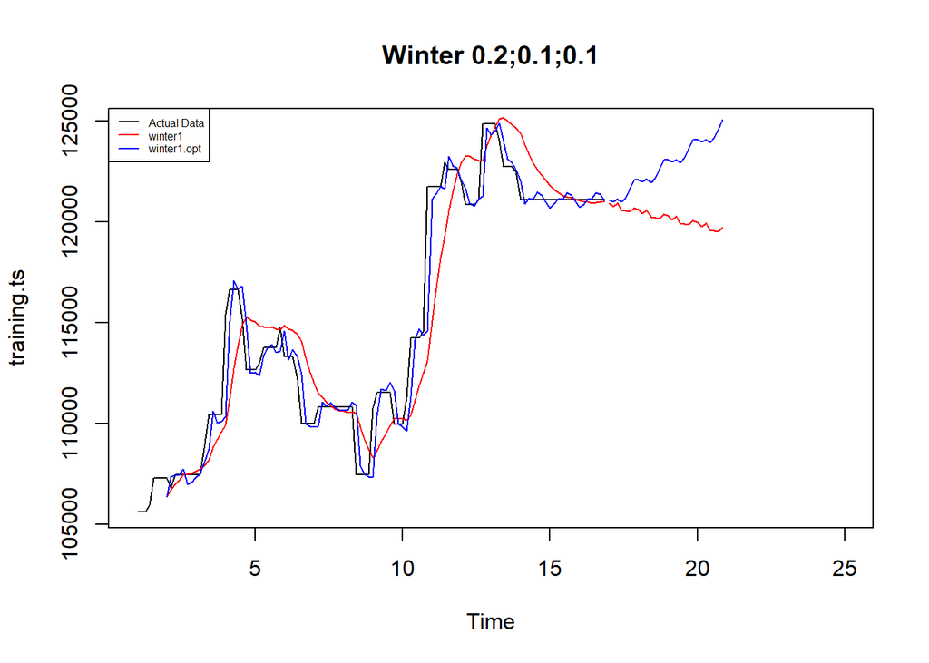

```r
#Plot time series
plot(training.ts,main="Winter 0.2;0.1;0.1",type="l",col="black",
     xlim=c(1,25),pch=12)
lines(xhat1,type="l",col="red")
lines(xhat1.opt,type="l",col="blue")
lines(forecast1,type="l",col="red")
lines(forecast1.opt,type="l",col="blue")
legend("topleft",c("Actual Data",expression(paste(winter1)),
                   expression(paste(winter1.opt))),cex=0.5,
       col=c("black","red","blue"),lty=1)
```

#### Akurasi Data Latih

```r
#Akurasi data training
SSE1<-winter1$SSE
MSE1<-winter1$SSE/length(training.ts)
RMSE1<-sqrt(MSE1)
akurasi1.train.wa <- matrix(c(SSE1,MSE1,RMSE1))
row.names(akurasi1.train.wa)<- c("SSE", "MSE", "RMSE")
colnames(akurasi1.train.wa) <- c("Akurasi")
akurasi1.train.wa
```

```
##           Akurasi
## SSE  5.470103e+08
## MSE  4.884020e+06
## RMSE 2.209982e+03
```

```r
SSE1.opt<-winter1.opt$SSE
MSE1.opt<-winter1.opt$SSE/length(training.ts)
RMSE1.opt<-sqrt(MSE1.opt)
akurasi1.opt.train <- matrix(c(SSE1.opt,MSE1.opt,RMSE1.opt))
row.names(akurasi1.opt.train)<- c("SSE1.opt", "MSE1.opt", "RMSE1.opt")
colnames(akurasi1.opt.train) <- c("Akurasi")
akurasi1.opt.train
```

```
##                Akurasi
## SSE1.opt  1.767789e+08
## MSE1.opt  1.578383e+06
## RMSE1.opt 1.256337e+03
```

```r
akurasi1.train.wa = data.frame(Model_Winter = c("Winter 1","Winter1 optimal"),
                            Nilai_SSE=c(SSE1,SSE1.opt),
                            Nilai_MSE=c(MSE1,MSE1.opt),Nilai_RMSE=c(RMSE1,RMSE1.opt))
akurasi1.train.wa
```

| Model_Winter | Nilai_SSE | Nilai_MSE | Nilai_RMSE |
| --- | --- | --- | --- |
| Winter 1 | 547010281 | 4884020 | 2209.982 |
| Winter1 optimal | 176778900 | 1578383 | 1256.337 |

#### Akurasi Data Uji

```r
#Akurasi Data Testing
forecast1<-data.frame(forecast1)
testing.ts<-data.frame(testing.ts)
selisih1<-forecast1-testing.ts
SSEtesting1<-sum(selisih1^2)
MSEtesting1<-SSEtesting1/length(testing.ts)

akurasi1.test.wa <- matrix(c(SSEtesting1,MSEtesting1))
row.names(akurasi1.test.wa)<- c("SSE", "MSE")
colnames(akurasi1.test.wa) <- c("Akurasi")
akurasi1.test.wa
```

```
##       Akurasi
## SSE 679429310
## MSE 679429310
```

```r
forecast1.opt<-data.frame(forecast1.opt)
selisih1.opt<-forecast1.opt-testing.ts
SSEtesting1.opt<-sum(selisih1.opt^2)
MSEtesting1.opt<-SSEtesting1.opt/length(testing.ts)

akurasi1.opt.test.wa <- matrix(c(SSEtesting1.opt,MSEtesting1.opt))
row.names(akurasi1.opt.test.wa)<- c("SSE", "MSE")
colnames(akurasi1.opt.test.wa) <- c("Akurasi")
akurasi1.opt.test.wa
```

```
##       Akurasi
## SSE 183531387
## MSE 183531387
```

### Winter Multiplikatif

Model multiplikatif digunakan cocok digunakan jika plot data asli menunjukkan fluktuasi musiman yang bervariasi.

#### Pemulusan

```r
#Pemulusan dengan winter multiplikatif
winter2 <- HoltWinters(training.ts,alpha=0.2,beta=0.1,gamma=0.3,seasonal = "multiplicative")
winter2$fitted
```

```
## Time Series:
## Start = c(2, 1)
## End = c(16, 7)
## Frequency = 7
##               xhat    level        trend    season
##  2.000000 106407.1 106371.7  141.4115646 0.9990052
##  2.142857 106226.2 106691.8  159.2867004 0.9941514
##  2.285714 107137.6 106966.6  170.8301874 1.0000022
##  2.428571 107082.6 107199.9  177.0774858 0.9972590
##  2.571429 108183.5 107450.6  184.4450459 1.0050954
##  2.714286 108033.8 107489.1  169.8490765 1.0034820
##  2.857143 107809.0 107542.6  158.2130182 1.0010048
##  3.000000 107889.4 107629.1  151.0396969 1.0010136
##  3.142857 107342.7 107692.3  142.2612269 0.9954388
##  3.285714 108076.3 107856.1  144.4162637 1.0007015
##  3.428571 108085.1 108135.2  157.8802871 0.9980796
##  3.571429 109349.0 108767.0  205.2690353 1.0034577
##  3.714286 109657.3 109191.7  227.2126437 1.0021791
##  3.857143 109842.5 109577.1  243.0317494 1.0002042
##  4.000000 110200.6 109941.6  255.1785967 1.0000345
##  4.142857 111113.4 111236.6  359.1638880 0.9956775
##  4.285714 113426.9 112707.9  470.3766419 1.0021967
##  4.428571 114733.3 113821.5  534.6973990 1.0032978
##  4.571429 115988.9 114738.3  572.9052151 1.0058776
##  4.714286 116164.6 115154.3  557.2191303 1.0039153
##  4.857143 115675.3 115011.4  487.2019815 1.0015303
##  5.000000 116618.9 114894.4  426.7884462 1.0112526
##  5.142857 115742.4 114536.3  348.2942680 1.0074671
##  5.285714 115664.9 114340.1  293.8524762 1.0089928
##  5.428571 115347.1 114254.4  255.8962299 1.0073070
##  5.571429 114901.8 114193.2  224.1868211 1.0042333
##  5.714286 113998.2 114188.0  201.2481554 0.9965812
##  5.857143 113987.2 114339.5  196.2668701 0.9952108
##  6.000000 115238.0 114689.0  211.5962278 1.0029362
##  6.142857 114883.3 114514.2  172.9497246 1.0017108
##  6.285714 115081.5 114371.0  141.3374983 1.0049705
##  6.428571 114715.1 114157.8  105.8835552 1.0039505
##  6.571429 114024.7 113762.6   55.7801767 1.0018125
##  6.714286 112545.2 113014.9  -24.5684731 0.9960602
##  6.857143 112044.7 112479.3  -75.6739461 0.9968070
```

[output cut: 55 more lines]

```
## 14.857143 122235.4 121946.1  -31.4780893 1.0026312
## 15.000000 121527.5 121688.2  -54.1274918 0.9991243
## 15.142857 121290.3 121548.5  -62.6854265 0.9983909
## 15.285714 121235.0 121447.7  -66.4974068 0.9987955
## 15.428571 120798.7 121354.1  -69.1998945 0.9959911
## 15.571429 120653.6 121345.4  -63.1499577 0.9948165
## 15.714286 120973.1 121372.0  -54.1757909 0.9971586
## 15.857143 121339.2 121343.3  -51.6313960 1.0003918
## 16.000000 120979.0 121243.8  -56.4133259 0.9982801
## 16.142857 120917.2 121211.7  -53.9891780 0.9980148
## 16.285714 120965.7 121194.3  -50.3251980 0.9985286
## 16.428571 120709.9 121170.9  -47.6362402 0.9965870
## 16.571429 120640.6 121201.5  -39.8066231 0.9956992
## 16.714286 120909.4 121254.0  -30.5798232 0.9974095
## 16.857143 121225.0 121261.6  -26.7579994 0.9999184
```

```r
xhat2 <- winter2$fitted[,2]

winter2.opt<- HoltWinters(training.ts, alpha= NULL,  beta = NULL, gamma = NULL, seasonal = "multiplicative")
winter2.opt$fitted
```

```
## Time Series:
## Start = c(2, 1)
## End = c(16, 7)
## Frequency = 7
##               xhat    level    trend    season
##  2.000000 106407.1 106371.7 141.4116 0.9990052
##  2.142857 106852.7 107339.9 141.4116 0.9941514
##  2.285714 107573.9 107432.3 141.4116 1.0000022
##  2.428571 107305.5 107459.0 141.4116 0.9972590
##  2.571429 108425.6 107734.5 141.4116 1.0050954
##  2.714286 107492.4 106978.0 141.4116 1.0034820
##  2.857143 107329.5 107080.3 141.4116 1.0010048
##  3.000000 107434.6 107333.1 141.4116 0.9996283
##  3.142857 106996.8 107488.8 141.4116 0.9941146
##  3.285714 108184.3 108052.0 141.4116 0.9999158
##  3.428571 108570.7 108716.8 141.4116 0.9973595
##  3.571429 111231.3 110601.3 141.4116 1.0044123
##  3.714286 110544.8 110023.1 141.4116 1.0034524
##  3.857143 110338.5 110077.1 141.4116 1.0010889
##  4.000000 110423.1 110321.5 141.4116 0.9996390
##  4.142857 114568.3 115068.7 141.4116 0.9944289
##  4.285714 117324.0 117146.7 141.4116 1.0003056
##  4.428571 116646.5 116664.8 141.4116 0.9986323
##  4.571429 117404.7 116809.5 141.4116 1.0038803
##  4.714286 115450.5 114919.2 141.4116 1.0033878
##  4.857143 112751.3 112478.7 141.4116 1.0011646
##  5.000000 112992.3 112526.5 141.4116 1.0028791
##  5.142857 112016.6 112352.2 141.4116 0.9957600
##  5.285714 113534.2 113407.2 141.4116 0.9998729
##  5.428571 113734.2 113748.3 141.4116 0.9986346
##  5.571429 114324.4 113904.3 141.4116 1.0024432
##  5.714286 113830.2 113515.7 141.4116 1.0015227
##  5.857143 113849.2 113583.0 141.4116 1.0010972
##  6.000000 115002.3 114556.8 141.4116 1.0026508
##  6.142857 112862.4 113127.6 141.4116 0.9964096
##  6.285714 113818.5 113675.4 141.4116 1.0000150
##  6.428571 113324.8 113337.1 141.4116 0.9986450
##  6.571429 112810.4 112436.6 141.4116 1.0020641
##  6.714286 110286.8 109983.5 141.4116 1.0014699
##  6.857143 110186.9 109860.0 141.4116 1.0016862
```

[output cut: 55 more lines]

```
## 14.857143 121622.3 121000.8 141.4116 1.0039632
## 15.000000 121052.8 120660.9 141.4116 1.0020734
## 15.142857 120940.0 120845.9 141.4116 0.9996088
## 15.285714 121250.9 121135.4 141.4116 0.9997864
## 15.428571 120881.5 121137.2 141.4116 0.9967258
## 15.571429 121369.2 121481.4 141.4116 0.9979152
## 15.714286 121614.3 121373.2 141.4116 1.0008200
## 15.857143 121621.7 121039.3 141.4116 1.0036389
## 16.000000 121095.4 120699.9 141.4116 1.0021027
## 16.142857 120951.6 120845.6 141.4116 0.9997078
## 16.285714 121228.5 121124.3 141.4116 0.9996931
## 16.428571 120907.4 121146.8 141.4116 0.9968606
## 16.571429 121334.6 121466.9 141.4116 0.9977490
## 16.714286 121593.2 121390.8 141.4116 1.0005017
## 16.857143 121619.5 121076.2 141.4116 1.0033152
```

```r
xhat2.opt <- winter2.opt$fitted[,2]
```

#### Peramalan

```r
#Forecast
forecast2 <- predict(winter2, n.ahead = 28)
forecast2.opt <- predict(winter2.opt, n.ahead = 28)
```

#### Plot Deret Waktu

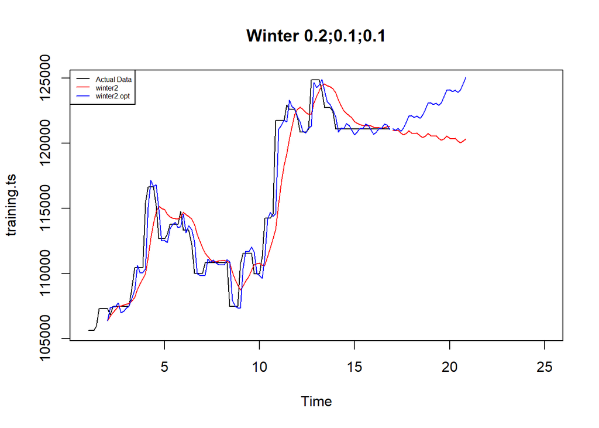

```r
#Plot time series
plot(training.ts,main="Winter 0.2;0.1;0.1",type="l",col="black",
     xlim=c(1,25),pch=12)
lines(xhat2,type="l",col="red")
lines(xhat2.opt,type="l",col="blue")
lines(forecast2,type="l",col="red")
lines(forecast2.opt,type="l",col="blue")
legend("topleft",c("Actual Data",expression(paste(winter2)),
                   expression(paste(winter2.opt))),cex=0.5,
       col=c("black","red","blue"),lty=1)
```

#### Akurasi Data Latih

```r
#Akurasi data training
SSE2<-winter2$SSE
MSE2<-winter2$SSE/length(training.ts)
RMSE2<-sqrt(MSE2)
akurasi1 <- matrix(c(SSE2,MSE2,RMSE2))
row.names(akurasi1)<- c("SSE2", "MSE2", "RMSE2")
colnames(akurasi1) <- c("Akurasi lamda=0.2")
akurasi1
```

```
##       Akurasi lamda=0.2
## SSE2       5.363107e+08
## MSE2       4.788489e+06
## RMSE2      2.188262e+03
```

```r
SSE2.opt<-winter2.opt$SSE
MSE2.opt<-winter2.opt$SSE/length(training.ts)
RMSE2.opt<-sqrt(MSE2.opt)
akurasi1.opt <- matrix(c(SSE2.opt,MSE2.opt,RMSE2.opt))
row.names(akurasi1.opt)<- c("SSE2.opt", "MSE2.opt", "RMSE2.opt")
colnames(akurasi1.opt) <- c("Akurasi")
akurasi1.opt
```

```
##                Akurasi
## SSE2.opt  1.783229e+08
## MSE2.opt  1.592169e+06
## RMSE2.opt 1.261812e+03
```

```r
akurasi2.train = data.frame(Model_Winter = c("Winter 1","winter2 optimal"),
                            Nilai_SSE=c(SSE2,SSE2.opt),
                            Nilai_MSE=c(MSE2,MSE2.opt),Nilai_RMSE=c(RMSE2,RMSE2.opt))
akurasi2.train
```

| Model_Winter | Nilai_SSE | Nilai_MSE | Nilai_RMSE |
| --- | --- | --- | --- |
| Winter 1 | 536310743 | 4788489 | 2188.262 |
| winter2 optimal | 178322915 | 1592169 | 1261.812 |

#### Akurasi Data Uji

```r
#Akurasi Data Testing
forecast2<-data.frame(forecast2)
testing.ts<-data.frame(testing.ts)
selisih2<-forecast2-testing.ts
SSEtesting2<-sum(selisih2^2)
MSEtesting2<-SSEtesting2/length(testing.ts)

forecast2.opt<-data.frame(forecast2.opt)
selisih2.opt<-forecast2.opt-testing.ts
SSEtesting2.opt<-sum(selisih2.opt^2)
MSEtesting2.opt<-SSEtesting2.opt/length(testing.ts)
```